# Analisis Customer Behavior untuk Mendukung Strategi Customer Relationship Management pada Database Sakila

SIM | CM1 | M0725001 | Alisia Surani

2026-05-21

## 1. Pendahuluan

Database Sakila merupakan database simulasi rental film yang disediakan oleh MySQL. Database ini berisi data mengenai pelanggan, film, transaksi rental, pembayaran, kategori film, dan berbagai informasi lainnya yang berkaitan dengan bisnis rental film.

Pada penelitian ini dilakukan analisis *customer behavior* untuk mendukung strategi *Customer Relationship Management*. Analisis difokuskan pada aktivitas pelanggan berdasarkan data transaksi rental dan pembayaran yang terdapat pada database Sakila.

Beberapa analisis yang dilakukan meliputi:

Analisis dilakukan menggunakan bahasa pemrograman R dengan memanfaatkan query SQL pada database Sakila. Hasil analisis divisualisasikan dalam bentuk dashboard dan grafik guna mempermudah interpretasi data dan pengambilan keputusan.

```r
### Menyiapkan Packages yang akan digunakan
library(DBI)
library(odbc)
library(dplyr)
library(ggplot2)
library(plotly)
library(scales)
library(DT)
```

```r
### Mengambil data dari sql

total_revenue <- dbGetQuery(sakila,
"SELECT SUM(amount) AS revenue FROM payment")

total_customer <- dbGetQuery(sakila,
"SELECT COUNT(*) AS customer FROM customer")

total_rental <- dbGetQuery(sakila,
"SELECT COUNT(*) AS rental FROM rental")

top_genre <- dbGetQuery(sakila,"
SELECT c.name, COUNT(*) AS total
FROM category c
JOIN film_category fc
ON c.category_id = fc.category_id
JOIN inventory i
ON fc.film_id = i.film_id
JOIN rental r
ON i.inventory_id = r.inventory_id
GROUP BY c.name
ORDER BY total DESC
LIMIT 1
")
```

### *Total Revenue*

$$TR = \sum_{i=1}^{n}
Payment_i$$

**keterangan:**

Total revenue digunakan untuk mengetahui total pendapatan yang diperoleh perusahaan dari seluruh total transaksi pembayaran pelanggan.

### *Total Customer*

$$TC = \sum_{i=1}^{n}
Customer_i$$

**keterangan:**

Total Customer digunakan untuk memperoleh informasi mengenai jumlah keseluruhan pelanggan yang terdaftar pada sistem rental film.

### *Total Rental*

$$TRen = \sum_{i=1}^{n}
Rental_i$$

**keterangan:**

Total Rental digunakan untuk mengetahui jumlah keseluruhan aktivitas rental film yang dilakukan pelanggan.

Total Revenue

$67406.56

Total Customer

599

Total Rental

16044

Top Genre

Sports

## 2. Analisis

Dalam analisis customer behavior, indikator yang dianalisis meliputi pelanggan dengan total pembayaran tertinggi (*high value customer*), pola aktivitas rental pelanggan, preferensi genre film pelanggan, serta hubungan antara aktivitas rental dan pembayaran pelanggan melalui correlation analysis. Analisis ini dilakukan untuk memahami perilaku pelanggan, mengetahui pelanggan yang memberikan kontribusi terbesar terhadap pendapatan perusahaan, serta mendukung penerapan strategi *Customer Relationship Management* yang lebih efektif dan tepat sasaran.

### 2.1 High Value Customer

#### 2.1.1 Mengambil data

```r
customer_value <- dbGetQuery(sakila, "
SELECT
    CONCAT(c.first_name, ' ', c.last_name) AS customer_name,
    SUM(p.amount) AS total_payment
FROM customer c
JOIN rental r
ON c.customer_id = r.customer_id
JOIN payment p
ON r.rental_id = p.rental_id
GROUP BY c.customer_id, customer_name
ORDER BY total_payment DESC
LIMIT 20
")
```

#### 2.1.2 Visualisasi

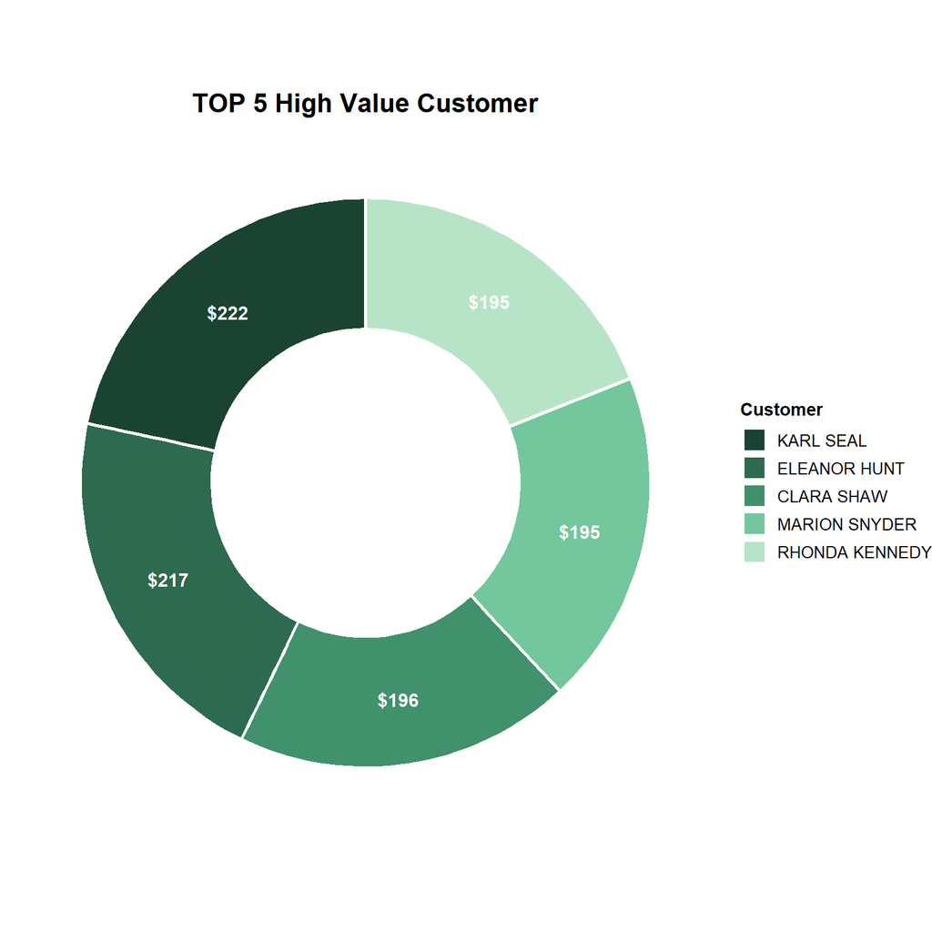

```r
customer_top5 <- customer_value %>%
  arrange(desc(total_payment)) %>%
  head(5)

greens <- c(
  "#1B4332",
  "#2D6A4F",
  "#40916C",
  "#74C69D",
  "#B7E4C7"
)

ggplot(customer_top5,
       aes(x=2,
           y=total_payment,
           fill=factor(customer_name,
                       levels=customer_name))) +

  geom_col(color="white",linewidth=1)+

  coord_polar(theta="y") +

  xlim(0.5, 2.5) +
  scale_fill_manual(values=greens) +

   geom_text(aes(label=paste0("$", round(total_payment,0))),
            position=position_stack(vjust=0.5),
            color="white",
            size=4,
            fontface="bold") +

  labs(
    title="TOP 5 High Value Customer",
    fill="Customer"
  ) +

  theme_void() +

  theme(
    plot.title = element_text(
      size=16,
      face="bold",
      hjust=0.5
    ),

    legend.position = "right",
    legend.title = element_text(face="bold"),
    legend.text = element_text(size=10)
  )
```

#### 2.1.3 Table TOP Customer

```r
datatable(customer_value,
          options = list(pageLength = 5),
          rownames = (FALSE))
```

| customer_name | total_payment |
| --- | --- |
| KARL SEAL | 221.55 |
| ELEANOR HUNT | 216.54 |
| CLARA SHAW | 195.58 |
| MARION SNYDER | 194.61 |
| RHONDA KENNEDY | 194.61 |
| TOMMY COLLAZO | 186.62 |
| WESLEY BULL | 177.6 |
| TIM CARY | 175.61 |
| MARCIA DEAN | 175.58 |
| ANA BRADLEY | 174.66 |

[output cut: 10 more lines]

#### 2.1.4 Intepretasi

**Intepretasi:**

Analisis data menunjukkan adanya kelompok high-value customers yang berkontribusi signifikan terhadap pendapatan perusahaan, dengan lima pelanggan teratas di antaranya adalah Karl Seal hingga Rhonda Kennedy. Dalam manajemen hubungan pelanggan (CRM), temuan ini sangat strategis untuk merancang program loyalitas, keanggotaan premium, serta promosi eksklusif yang ditujukan untuk menjaga retensi pelanggan potensial tersebut.

### 2.2 Customer Activity Pattern

#### 2.2.1 Mengambil Data

```r
activity_pattern <-dbGetQuery(sakila, "
SELECT
DAYNAME(rental_date) AS day_name,
HOUR(rental_date)  AS hour_rental,
COUNT(*) AS total_rental
FROM rental
GROUP BY day_name, hour_rental
")
```

#### 2.2.2 Visualisasi

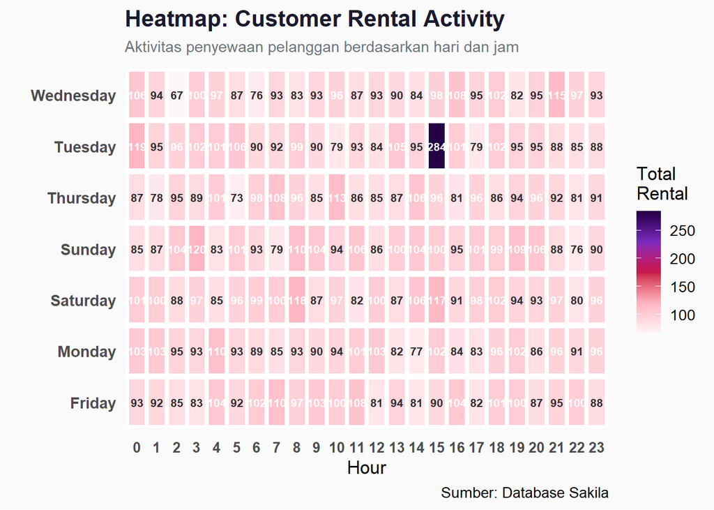

```r
activity_pattern$total_rental <-
  as.numeric(activity_pattern$total_rental)

ggplot(activity_pattern,
       aes(x = factor(hour_rental),
           y = day_name,
           fill = total_rental)) +

  geom_tile(color = "white",
            linewidth = 1.2,
            width = 0.95,
            height = 0.95) +

  geom_text(aes(label = total_rental),
            size = 2.8,
            fontface = "bold",
            color = ifelse(activity_pattern$total_rental >
                             mean(activity_pattern$total_rental),
                           "white",
                           "#2d2d2d")) +

  scale_fill_gradientn(
    colours = c("#FFF5F7",
                "#FFB3C1",
                "#C9184A",
                "#7B2CBF",
                "#240046"),
    name = "Total\nRental"
  ) +

  labs(
    title = "Heatmap: Customer Rental Activity",
    subtitle = "Aktivitas penyewaan pelanggan berdasarkan hari dan jam",
    x = "Hour",
    y = "",
    caption = "Sumber: Database Sakila"
  ) +

  theme_minimal(base_size = 13) +

  theme(
    plot.title = element_text(
      face = "bold",
      size = 16,
      color = "#1a1a2e"
    ),

    plot.subtitle = element_text(
      size = 11,
      color = "#6c757d"
    ),

    axis.text.x = element_text(
      face = "bold",
      size = 10
    ),

    axis.text.y = element_text(
      face = "bold",
      size = 11
    ),

    panel.grid = element_blank(),

    plot.background = element_rect(
      fill = "#fafafa",
      color = NA
    ),

    panel.background = element_rect(
      fill = "#fafafa",
      color = NA
    )
  )
```

### 2.3 Genre Reference

#### 2.3.1 Mengambil Data

```r
genre_pref <- dbGetQuery(sakila,"
SELECT
c.name AS category,
COUNT(r.rental_id) AS total_rental,
SUM(p.amount) AS total_revenue
FROM category c
JOIN film_category fc
ON c.category_id = fc.category_id
JOIN inventory i
ON fc.film_id = i.film_id
JOIN rental r
ON i.inventory_id = r.inventory_id
JOIN payment p
on r.rental_id = p.rental_id
GROUP BY c.name
ORDER BY total_rental
DESC")
```

#### 2.3.2 Visualisasi

```r
p2 <- ggplot(genre_pref,
             aes(x = reorder(category, total_rental),
                 y = total_rental,
                 text = paste(
                   "Genre:", category,
                   "<br>Total Rental", total_rental
                 ))) +
  geom_col(fill="#415A77") + coord_flip() +
  labs(
    title = "Genre Preference Based on Rental Activity",
    x = "Genre",
    y = "Total Rental" ) +
  theme_minimal(base_size = 13)

ggplotly(p2, tooltip = "text")
```

[interactive chart not shown]

#### 2.3.3 Intepretasi

**Intepretasi:**

Berdasarkan grafik “Genre Preference Based on Rental Activity”, terlihat perbedaan preferensi pelanggan yang jelas terhadap kategori film yang disewa. Genre Sports, Animation, dan Action menjadi tiga kategori paling populer dengan volume penyewaan tertinggi mendekati 1.200 transaksi, sementara Horror, Travel, dan Music menempati posisi terendah. Data preferensi ini dapat memberikan landasan strategis bagi manajemen dalam mengoptimalkan pengadaan inventaris film berbasis genre terpopuler. Selain itu, informasi ini sangat berguna untuk menyusun strategi CRM, seperti penargetan promosi yang dipersonalisasi dan pengembangan sistem rekomendasi film yang lebih akurat guna meningkatkan kepuasan serta loyalitas pelanggan.

### 2.4 Correlation Analysis

#### 2.4.1 Mengambil Data

```r
customer_corr <- dbGetQuery(sakila,"
SELECT
    c.customer_id,
    COUNT(r.rental_id) AS total_rental,
    SUM(p.amount) AS total_payment
FROM customer c
JOIN rental r
ON c.customer_id = r.customer_id
JOIN payment p
ON r.rental_id = p.rental_id
GROUP BY c.customer_id
")
```

#### 2.4.2 Visualisasi

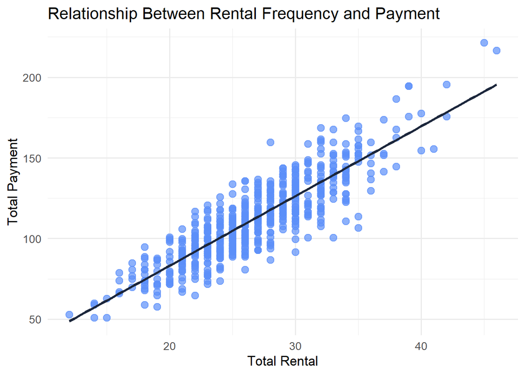

```r
ggplot(customer_corr,
       aes(x=total_rental,
           y=total_payment)) +

  geom_point(color="#5B8FF9",
             size=3,
             alpha=0.7) +

  geom_smooth(method="lm",
              se=FALSE,
              color="#1B263B") +

  labs(
    title="Relationship Between Rental Frequency and Payment",
    x="Total Rental",
    y="Total Payment" ) +

  theme_minimal(base_size = 13)
```

#### 2.4.3 Intepretasi

**Intepretasi:**

Berdasarkan grafik scatter plot pada bagian “Correlation Analysis”, terdapat hubungan positif yang kuat antara Total Rental dan Total Payment. Pola data menunjukkan bahwa semakin sering pelanggan menyewa, semakin besar pula pendapatan yang diterima perusahaan. Implikasinya, perusahaan perlu fokus membuat program yang menjaga agar pelanggan terus menyewa secara berulang. Strategi ini bisa dilakukan dengan memberikan reward atau diskon khusus setelah mereka mencapai jumlah penyewaan tertentu, sehingga pelanggan merasa untung dan terus bertransaksi dalam jangka panjang.

## Kesimpulan

Analisis *customer behavior* menggunakan database Sakila memberikan pemahaman mendalam yang sangat strategis bagi optimalisasi *Customer Relationship Management* (CRM) perusahaan. Hasil evaluasi data menunjukkan adanya hubungan linear positif yang kuat antara Total Rental dan jumlah pembayaran *Total Payment*. Hal ini mengonfirmasi bahwa loyalitas pelanggan dalam melakukan transaksi berulang berdampak langsung pada peningkatan pendapatan perusahaan, dengan kelompok *high-value customers* seperti Karl Seal hingga Rhonda Kennedy sebagai kontributor finansial terbesar. Di sisi lain, aktivitas transaksional ini juga sangat dipengaruhi oleh faktor waktu dan preferensi produk. Pola operasional harian menunjukkan adanya lonjakan trafik yang signifikan pada hari Selasa pukul 15.00 sebagai waktu puncak (*peak activity*), sementara preferensi konten pelanggan didominasi secara kuat oleh genre *Sports*, *Animation*, dan *Action*.

Berdasarkan temuan-temuan tersebut, strategi CRM ke depan harus difokuskan pada upaya retensi yang dipersonalisasi dan efisiensi operasional. Perusahaan dapat mempertahankan kelompok pelanggan bernilai tinggi melalui program loyalitas berbasis volume, seperti pemberian *reward* atau diskon progresif, serta penawaran keanggotaan premium. Selain itu, data diatas dan preferensi genre dapat digunakan sebagai landasan dalam merancang program pemasaran yang lebih presisi, misalnya dengan meluncurkan promo *happy hour* pada jam sibuk hari Selasa, memberikan insentif khusus pada periode sepi untuk meratakan keterisian rental, serta memprioritaskan pengadaan inventaris pada kategori film yang paling populer guna memaksimalkan kepuasan dan loyalitas pelanggan dalam jangka panjang.

Sistem Informasi Manajemen - Statistika 2025 - Universitas Sebelas Maret